# Wednesday, September 23rd, 2026

Last class, we discussed list slicing and list comprehension. In particular, we can generate slices of a list in the following ways:

- `my_list[start_index:]` will start the slice at `start_index` and go the end of the list.
- `my_list[:stop_index]` will start the slice at the beginning of the list (i.e. index `0`) and proceed until one less than `stop_index`.
- `my_list[start_index:stop_index]` will start the slice at `start_index` and proceed until one less than `stop_index`.
- `my_list[::skip]` will start the slice at the beginning of the list and go to the end, but will go in steps of `skip`.
- `my_list[start_index:stop_index:skip]` will start at `start_index`, proceed in steps of `skip`, and will stop when the index is greater than or equal to `stop_index`.

We can use list comprehension in the following ways:

- `[<some expression> for <some item> in <some iterable>]` will generate a list by looping through each element of `<some iterable>`, assigning the element to the variable name `<some item>`, and storing the result of `<some expression>` in the list.
- `[<some expression> for <some item> in <some iterable> if <some condition>]` will work similarly, except the result of `<some expression>` will only be stored in the list of `<some condition>` is `True`.

**Exercise:** Use list comprehension to generate a list `cubes` containing the cubes of the first $40$ positive integers.

```python
cubes = []
for i in range(1,41):
    cubes.append(i**3)
```

```python
cubes = [i**3 for i in range(1,41)]
```

```python
print(cubes)
```

```
[1, 8, 27, 64, 125, 216, 343, 512, 729, 1000, 1331, 1728, 2197, 2744, 3375, 4096, 4913, 5832, 6859, 8000, 9261, 10648, 12167, 13824, 15625, 17576, 19683, 21952, 24389, 27000, 29791, 32768, 35937, 39304, 42875, 46656, 50653, 54872, 59319, 64000]
```

**Exercise:** Use list slicing to print out the third through tenth of these cubes (i.e. index-`2` through index-`9`).

```python
print(cubes[2:10])
```

```
[27, 64, 125, 216, 343, 512, 729, 1000]
```

**Exercise:** Use list slicing to print out the last ten cubes from the `cubes` list.

```python
print(cubes[30:])
```

```
[29791, 32768, 35937, 39304, 42875, 46656, 50653, 54872, 59319, 64000]
```

```python
print(cubes[-10:])
```

```
[29791, 32768, 35937, 39304, 42875, 46656, 50653, 54872, 59319, 64000]
```

```python
print(cubes[len(cubes)-10:])
```

```
[29791, 32768, 35937, 39304, 42875, 46656, 50653, 54872, 59319, 64000]
```

**Exercise:** Use list comprehension to generate a list containing, out of the cubes of the first $40$ positive integers, only those that are divisble by $6$.

```python
cubes_div_by_6 = []
for cube in cubes:
    if cube % 6 == 0:
        cubes_div_by_6.append(cube)
```

```python
cubes_div_by_6 = [cube for cube in cubes if (cube % 6 == 0)]
```

```python
print(cubes_div_by_6)
```

```
[216, 1728, 5832, 13824, 27000, 46656]
```

## Mutable and immutable objects

The word *mutable* means "liable to change." Consider the following experiments in which we explore how Python handles changing variables.

Experiment #1:

```python
n = 3
m = n

print('n = {}'.format(n))
print('m = {}'.format(m))
```

```
n = 3
m = 3
```

What happens to `m` if we make changes to `n`?

```python
n = n + 5

print('n = {}'.format(n))
print('m = {}'.format(m))
```

```
n = 8
m = 3
```

We see that `m` is unchanged when `n` is changed.

Experiment #2:

```python
list1 = [1,2,3,4]
list2 = list1

print('list1 =',list1)
print('list2 =',list2)
```

```
list1 = [1, 2, 3, 4]
list2 = [1, 2, 3, 4]
```

What happens to `list2` if we make changes to `list1`?

```python
list1[0] = 99

print('list1 =',list1)
print('list2 =',list2)
```

```
list1 = [99, 2, 3, 4]
list2 = [99, 2, 3, 4]
```

This time, we see that `list2` *is* changed when `list1` is changed.

What's going on here? Setting `m = n` did not cause changes in `n` to propogate back to `m`, but in the list example, setting `list2=list1` did cause changes to `list1` to propogate to `list2`.

The difference is that integers are *immutable objects* in Python while lists are *mutable* obects.

- Immutable objects:
  - Integers
  - Strings
  - Floats
  - Booleans
  - Tuples
- Mutable objects:
  - Lists
  - Dictionaries
  - Sets
  - NumPy arrays

For mutable objects, variable assigments point to a place in memory that stores the obect (in this case a list). That is, `list1` and `list2` point to the same location in memory. Making modifications to the object modifies the values stored in this shared memory location, so all variables pointing to this location are affected. We can use the `id` function to get an identifier for the memory location of an object.

```python
id(m)
```

```
140711861531624
```

```python
id(n)
```

```
140711861531784
```

```python
id(list1)
```

```
2279988316160
```

```python
id(list2)
```

```
2279988316160
```

We can check whether two variables have the same ID to see whether they share the same memory location (so that changes to one affect the other).

```python
id(list1) == id(list2)
```

```
True
```

```python
list1 = [1,2,3,4]
list2 = list1
list3 = [1,2,3,4]
```

```python
id(list1)
```

```
2279987984768
```

```python
id(list2)
```

```
2279987984768
```

```python
id(list3)
```

```
2279988362752
```

```python
list1[0] = 99
print(list1)
print(list2)
print(list3)
```

```
[99, 2, 3, 4]
[99, 2, 3, 4]
[1, 2, 3, 4]
```

```python
list3.append(5)

print(list1)
print(list2)
print(list3)
```

```
[99, 2, 3, 4]
[99, 2, 3, 4]
[1, 2, 3, 4, 5]
```

```python
id(list3) == id(list1)
```

```
False
```

Alternatively, we can use the `is` operator to check if two variables refer to the same object in memory.

```python
list1 is list2
```

```
True
```

```python
list1 is list3
```

```
False
```

```python
list1 = [1,2,3,4]
list2 = list1
list1 = [5,6,7,8]

print(list1)
print(list2)
```

```
[5, 6, 7, 8]
[1, 2, 3, 4]
```

```python
list1 is list2
```

```
False
```

```python
list1 = [1,2,3,4]
list2 = list1
list1[:] = [5,6,7,8]

print(list1)
print(list2)
```

```
[5, 6, 7, 8]
[5, 6, 7, 8]
```

Sometimes, we may want to copy a list to a new variable but sever this link. That is, we might want a new variable (pointing to a new location in memory) that has the same values. To do this, we can use the `.copy()` method:

```python
list1 = [1,2,3,4]
list2 = list1.copy()

print(list1)
print(list2)

list1 is list2
```

```
[1, 2, 3, 4]
[1, 2, 3, 4]
```

```
False
```

```python
list1.append(5)

print(list1)
print(list2)
```

```
[1, 2, 3, 4, 5]
[1, 2, 3, 4]
```

## More about function inputs

### Positional and keyword arguments

So far, we've discussed defining functions that take in some number of input variables. For example, let's define a function `y` that takes in four inputs $t$, $a$, $b$, $c$, and evalutates the quadratic $at^2 + bt + c$.

```python
def y(t,a,b,c):
    return a*t**2 + b*t + c
```

When we call a function, we can simply enter values in the corresponding order to map them to the input variables. For example, calling `y(0,1,2,3)` will execute the function by mapping `t=0`, `a=1`, `b=2`, and `c=3`.

```python
y(0,1,2,3)
```

```
3
```

Sometimes, it is useful to explicitly assign values to variables. This can be done using **keyword arguments**. To use a keyword argument, we plug a mapping `<variable name> = <value>` into the function.

For example, calling `y(t=0, a=1, b=2, c=3)` will explicitly map `t=0`, `a=1`, `b=2`, and `c=3` and then execute the function's code.

```python
y(t=0, a=1, b=2, c=3)
```

```
3
```

With keyword arguments, we do not need to enter the values in the same order that was used to define the function. That is, `y(a=1, b=2, c=3, t=0)` will give the same result as `y(0,1,2,3)`, whereas `y(1,2,3,0)` would map `t=1`, `a=2`, `b=3`, `c=0`.

```python
y(c=3, a=1, b=2, t=0)
```

```
3
```

When calling a function, inputs that we've not explicitly labeled as keyword arguments are called **positional arguments**. All positional arguments must come before *any* keyword arguments, and their ordering determines the mapping to the input variable names.

```python
y(0, 1, c=3, b=2)
```

```
3
```

```python
y(t=0, a=1, 2, 3)
```

```
  Cell In[44], line 1
    y(t=0, a=1, 2, 3)
                    ^
SyntaxError: positional argument follows keyword argument
```

### Default parameters

It often happens that we write a function that takes in an input variable that has a natural or typically useful value. For example, suppose we want to use the `y` function to model an object in freefall due to gravity using the quadratic expression,

$$y(t) = at^2 + bt + c.$$

Note: the acceleration of the object is $y''(t) = 2a$ and the initial velocity is $y'(0) = b$. It might be typical that we are considering an object in freefall on Earth, where the acceleration due to gravity is approximately $-9.8\,m/s^2$ (or $a \approx -4.9$). We also might be often interested in modeling an object that is released from rest (with zero initial velocity, or $b=0$).

In situations like this, we can assign a default value to the input variables `a` and `b` when we define the function `t`. To do so, we use the syntax `def <some function>(<some variable>=<default value>):`. Let's modify the `y` function to default to `a=-4.9` and `b=0`.

```python
def y(t,c,a=-4.9,b=0):
    return a*t**2 + b*t + c
```

```python
y(10,1000) # Height of an object 10 seconds after falling from 1000m on Earth
```

```
509.99999999999994
```

```python
y(10,1000, a=-3.7/2) # Height of an object 10 seconds after falling from 1000m on Mars
```

```
815.0
```

Given the physical model, it might be a good idea to use better names than `a`, `b`, `c`. For example, we could rephrase the function parameters in terms of the initial velocity $v_0$ and the initial height $y_0$.

```python
def y(t,y0,g=-9.8,v0=0):
    return (g/2)*t**2 + v0*t + y0
```

```python
y(10, 1000, g=-3.7, v0=100)
```

```
1815.0
```

Given this function, it would be nice if we had a way to visualize the paths taken by objects in freefall. This leads us to...

## Plotting in Python

We will the `pyplot` submodule from the `matplotlib` module for our plotting needs. When importing modules (or submodules), we can assign our own short-hand name using the syntax `import <some module or submodule> as <some short-hand name>`.

Typically, we will import the `matplotlib.pyplot` module and assign it the short-hand name `plt`.

```python
import matplotlib.pyplot as plt
```

The `pyplot` module includes *many* functions for data visualization and plotting. The most basic is the `plot` function.

```python
#help(plt)
```

```python
#help(plt.plot)
```

The `plot` function is extremely flexible in how it can be called (by making use of default parameters and keyword arguments). One of the most basic ways to use the `plot` function is to enter a list of $x$-values and a list of $y$-values as inputs. That is, `plt.plot(<list of x-values>, <list of y-values>)`.

```python
x_list = [i for i in range(1,11)]
y_list = [x**2 for x in x_list]
```

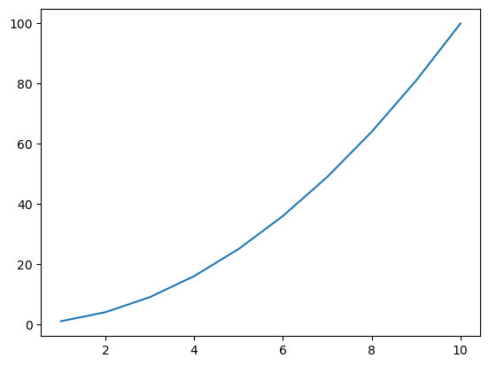

```python
plt.plot(x_list, y_list)
```

**Exercise:** Use the function `y` defined previously to plot the height over time of an object dropped (from rest) from a height of $1,000$ meters (on Earth) for the range $0 \leq t \leq 16$.

```python
t_list = [t for t in range(17)]
y_list = [y(t, 1000) for t in t_list]
```

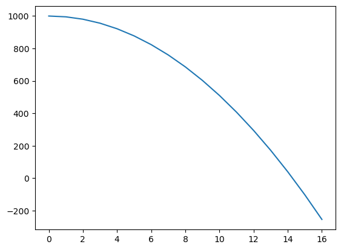

```python
plt.plot(t_list, y_list)
```

We can call `plt.plot` several times within a cell to plot several pieces of data.

**Exercise:** Replicate the previous plot, then add another curve that shows the height over time of the same object dropped on Mars, where the acceleration due to gravity is approximately $-3.71\, m/s^2$.

```python
y0 = 1000      # Initial height
g_Earth = -9.8 # Gravitational constant on Earth
g_Mars = -3.7  # Gravitational constant on Mars

t_list = [t for t in range(17)]
y_Earth_list = [y(t, y0, g_Earth) for t in t_list]
y_Mars_list = [y(t, y0, g=g_Mars) for t in t_list]
```

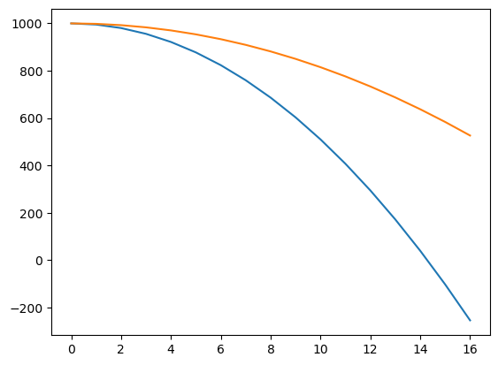

```python
plt.plot(t_list, y_Earth_list)
plt.plot(t_list, y_Mars_list)
```